# SQL Tutorial

Confidential: Property of the Data Jedi Academy, unauthorised distribution not allowed

[figure not shown]

## SQL Tutorial: Basic Introduction

### Introduction

Structured Query Language (SQL) is used to perform operations on data in a database. SQL statements are used to perform tasks such as update data on a database, or retrieve data from a database. Some common relational database management systems that use SQL are: Oracle, Microsoft SQL Server, MySQL,Postgres etc. Although most database systems use SQL, most of them also have their own additional proprietary extensions that are usually only used on their system. SQL language reads like plain English language. Making it intuitive for new users.

[About SQL](http://www.sqlcourse.com/intro.html)

Content

1. Relational Databases
2. SQL Command Types
3. SQL flavors
4. Hands on tutorial

### 1. Relational Databases

A relational database organizes data into tables which can be linked—or related—based on data common to each. This capability enables you to retrieve an entirely new table from data in one or more tables with a single query. It also allows you and your business to better understand the relationships among all available data and gain new insights for making better decisions or identifying new opportunities.

For example, imagine your company maintains a customer table that contains company data about each customer account and one or more transaction tables that contain data describing individual transactions.

The columns (or fields) for the customer table might be Customer ID, Company Name, Company Address, etc.; the columns for a transaction table might be Transaction Date, Customer ID, Transaction Amount, Payment Method, etc. The tables can be related based on the common Customer ID field. You can, therefore, query the table to produce valuable reports, such as a consolidated customer statement.

Report generators take these queries and run them on demand to create formal reports. Many of the documents businesses run to track inventory, sales, finance, or even perform financial projections come from a relational database operating behind the scenes.

[Introduction to Relational Databases](https://www.ibm.com/cloud/learn/relational-databases)

### 2. SQL Command Types

SQL uses various commands for different operations. We will learn about the like DDL, DML,DCL, TCL and DQL commands. To understand this better, we will use analogies in Microsoft Excel (MS Excel) which you are probably more familiar with.

#### What is DDL

Data Definition Language helps you to define the database structure or schema. DDL can be likened to creating a new Excel workbook or tab and defining a table with specific columns. The columns defined determine the type of data which will be expected.

#### What is DML

Data Manipulation Language (DML) allows you to modify the database instance by inserting, modifying, and deleting its data. It is responsible for performing all types of data modification in a database. DML is similar to inserting, deleting or updating columns in Excel.

#### What is DCL

DCL (Data Control Language) includes commands like GRANT and REVOKE, which are useful to give “rights & permissions.” Other permission controls parameters of the database system. DCL is similar to locking cells and columns in MS Excel to restrict access.

#### What is DQL

Data Query Language (DQL) is used to fetch the data from the database. DQL is similar to opening an existing MS Excel file to view data and als writing various formulas and viewing the results.

[SQL Command Types](https://www.guru99.com/sql-commands-dbms-query.html)

This course will focus mainly on DQL. Typically the other commad types are handled by a database administrator or data engineer within an organisation.

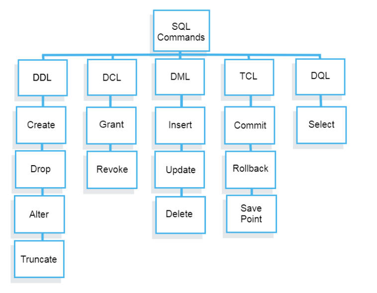

### 3. SQL Flavors

Common relational database management systems that use SQL (Oracle, Microsoft SQL Server, MySQL etc.) typically have their own additional proprietary extensions that are usually only used on their system. This means some SQL statements written in Oracle may not work on Microsoft SQL Server and vice versa. Although they all have some common statements which will work across board, nuances still exist in the way specific operations are performed giving rise to the differences.

An easy way to understand this is to look at the English Language. Even though some parts of the language is common across board there are still nuances peculiar to different regions.

We have American English, British English and Nigerian English.

British English - Have you done your homework yet?

American English - Did you do your homework yet?

Nigerian English - Have you finished your homework?

The statement below selects the details of 10 customers from a customer table. It clearly shows the nuances of these various systems.

Microsoft SQL Server (TSQL) - SELECT TOP 10 * FROM customer;

Oracle (PLSQL) - SELECT * FROM customer WHERE ROWNUM <= 10;

MySQL (SQL) - SELECT * FROM customer LIMIT 10;

### 4. Hands on Tutorial

For the hands on tutorial, we will be using a platform called Mode Analytics to learn SQL. It is an analytics platform which has an online SQL module.

Over the next 2 weeks, you will learn SQL on Mode and the topics will vary from beginner concepts to more advanced concepts. After the learning for the week, you will have an exercise to complete using the data for the project. To complete this exercise, you will use the MySQL and complete the exercises in a Jupyter notebook.

#### Week 1 Tutorial

Get started in SQL by completing the "Basic SQL" module on Mode. Feel free to move to the "Intermediate SQL" module if you finish the basic module in record time

https://mode.com/sql-tutorial/

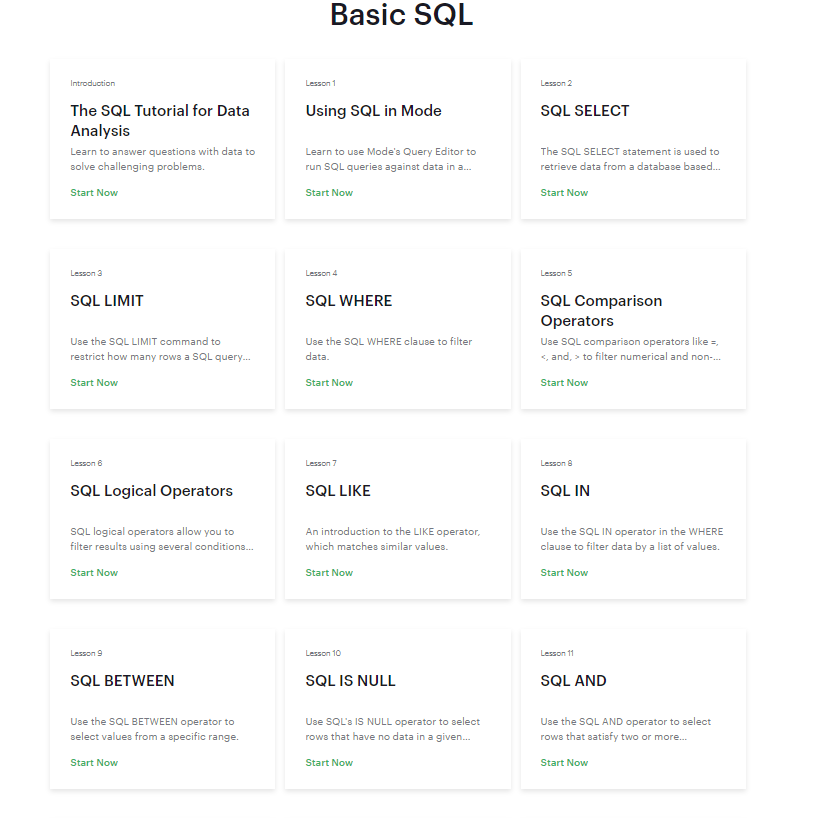

#### Week 1 SQL Setup - Installation

You will be using MySQL to complete the exercises. MySQL is an open-source relational database management system (RDBMS). You can install it by following the video in the link below. You will be using the MySQL workbench which a graphical user interface for interacting with MySQL seamlessly.

https://www.youtube.com/watch?v=OM4aZJW_Ojs

[figure not shown]

#### Week 1 SQL Setup - MySQL workbench Walkthrough Video

The video in the link below provides a quick walkthrough of the MySQL workbench to help you understand the interface. After the walkthrough you can import your data to start exploring in the next section of the setup.

https://www.youtube.com/watch?v=Wk4J2poX7Fo

#### Week 1 SQL Setup - Import data

Create a database called "salesdb" and import your data from CSV into your database. Use the video in the link below to complete this

https://www.youtube.com/watch?v=pBx7Y4SE1i4

#### Week 1 Exercise

Based on the knowledge you have gleaned, write SQL statements to answer the following:

- Identify customers who live either Germany, UK or US
- Identify customers who do not have a country assigned to them
- Identify customers from UK and US whose names have the word "market" in them

#### Week 2 Tutorial

Get started in SQL by completing the "Intermediate SQL" and "Advanced SQL" modules on Mode

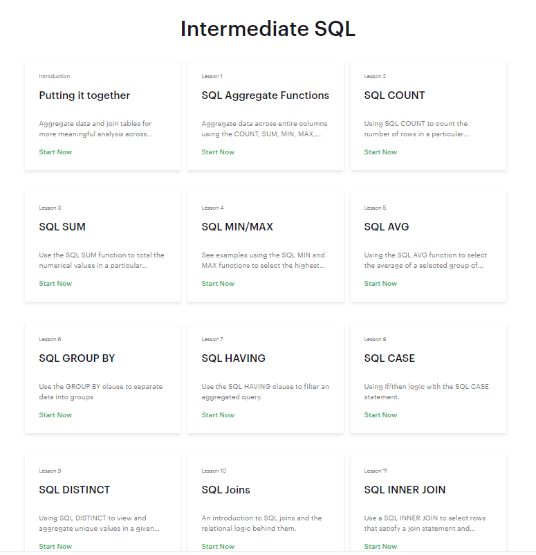

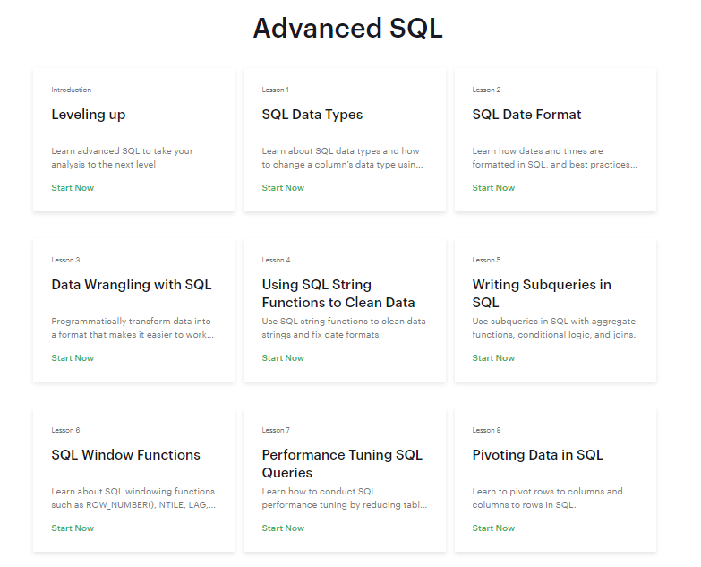

#### Week 2 Exercise

Based on the knowledge you have gleaned, write SQL statements that provide management with reports which will give insights and aid decision making. Also ensure you add a little write up on your insights based on the data generated:

- Commence a loyalty program for our top customers
- Make more investment into locations with highest sales
- Make more investment into products with highest sales and profitability
- Commence a reward program for our most hard working workers
- Identify key customer segments within the beverage product line to prioritize. Use the [RFM segmentation model](https://www.moengage.com/blog/rfm-analysis-using-rfm-segments/) for this

**Reference materials**

1. [About SQL](http://www.sqlcourse.com/intro.html)
2. [Introduction to Relational Databases](https://www.ibm.com/cloud/learn/relational-databases)
3. [SQL Command Types](https://www.guru99.com/sql-commands-dbms-query.html)
4. [RFM segmentation model](https://www.moengage.com/blog/rfm-analysis-using-rfm-segments/)